# LargeST: reproduce the two regional flow maps

This tutorial reproduces the Los Angeles and Bay Area **data layers** in the repository’s LargeST visualization for July 31, 2019. The standalone dataset, extracted losslessly from the HTML, contains actual saved sensor and display-link series for 288 five-minute frames. No original HDF5 download, synthetic replacement, fitting or browser execution is needed.

## Read the standalone visualization dataset

Install `bdynets` and `jsonlite`; rendering also requires `rmarkdown` and `knitr`. The reader loads standalone JSON and records its MD5 and original HTML SHA-256.

```r
library(bdynets)
snapshot <- read_traffic_data(params$snapshot)
snapshot$provenance
```

```
## $file
## [1] "largest-visualization.json.gz"
##
## $md5
## [1] "4f63a05a91ce300afb32c7c87ab43a05"
##
## $source_html
## [1] "largest_la_bay_area_flow_2019_07_31.html"
##
## $source_sha256
## [1] "8da4eeb1058ab57bb32943dc7c87bf2bf668ba4c43ccf3d54867e6060760b60b"
##
## $representation
## [1] "saved HTML display precision; extracted without recalculation"
```

```r
lapply(snapshot$data$regions, function(region) region$summary)
```

```
## $`Los Angeles Area`
## $`Los Angeles Area`$sensors
## [1] 3834
##
## $`Los Angeles Area`$links
## [1] 3699
##
## $`Los Angeles Area`$counties
## $`Los Angeles Area`$counties[[1]]
## [1] "Los Angeles"
##
## $`Los Angeles Area`$counties[[2]]
## [1] "Orange"
##
## $`Los Angeles Area`$counties[[3]]
## [1] "Riverside"
##
## $`Los Angeles Area`$counties[[4]]
## [1] "San Bernardino"
##
## $`Los Angeles Area`$counties[[5]]
## [1] "Ventura"
##
##
## $`Los Angeles Area`$freeways
## [1] 58
##
##
## $`Bay Area`
## $`Bay Area`$sensors
## [1] 2348
##
## $`Bay Area`$links
## [1] 2296
##
## $`Bay Area`$counties
## $`Bay Area`$counties[[1]]
## [1] "Alameda"
##
## $`Bay Area`$counties[[2]]
```

[output cut: 11 more lines]

```
## $`Bay Area`$counties[[6]]
## [1] "San Mateo"
##
## $`Bay Area`$counties[[7]]
## [1] "Santa Clara"
##
## $`Bay Area`$counties[[8]]
## [1] "Solano"
##
## $`Bay Area`$counties[[9]]
## [1] "Sonoma"
##
##
## $`Bay Area`$freeways
## [1] 40
```

Sensor observations and display links are separate. The original visualization constructed links between selected sensors and assigned endpoint-averaged flow values. The importer retains those saved links and rounded values; it does not promote them to physical connectivity or model adjacency. Null values remain missing and use the original gray color.

## Reproduce the original default time

The original viewer opens at 16:10, JavaScript index 194. The corresponding one-based R index is 195. Both regions use their own saved quantile thresholds, so identical colors do **not** imply identical flow across regions.

```r
frames <- traffic_figures(params$snapshot, "largest", time_index=195L)
```

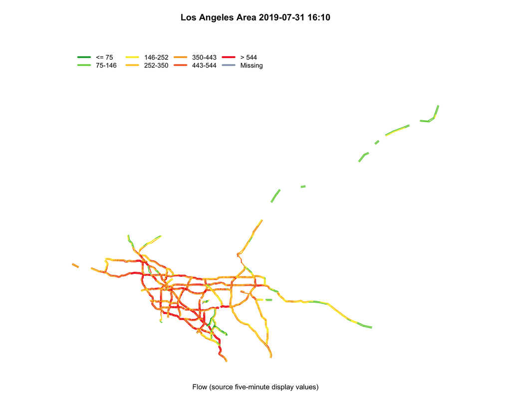

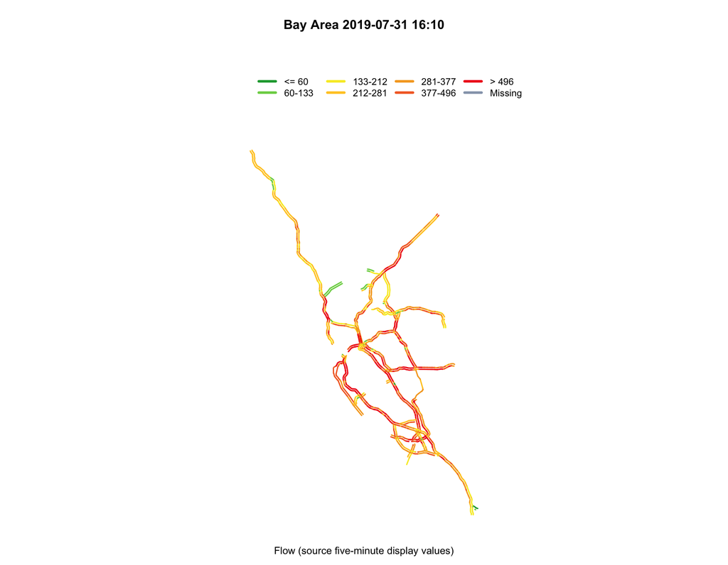

The maps retain the source seven-color scale, geographic link geometry and opposite-direction offsets at each region’s source zoom. Flow values are those saved in the viewer. Geometry is projected to Web Mercator. Remote basemap tiles, place labels and browser controls are omitted; static line widths are adapted to the graphics device. These are data-layer reproductions, not pixel-identical screenshots or a reconstruction of the full road network.

## Choose a region, time and export destination

```r
frame <- traffic_frame(snapshot, time_index=97L, region="Bay Area")
plot(frame) # 08:00
traffic_figures(params$snapshot, "largest", time_index=97L,
                output_dir="/path/to/new/largest-0800")
```

The export writes both regional maps as PDF/PNG, source identity, frame selection and session information. It refuses existing named outputs. For statistical analysis, use the sensor-level series and documented graph construction rather than treating display-link averages as independent count observations.

```r
lapply(snapshot$data$regions, function(region) unlist(region$breaks))
```

```
## $`Los Angeles Area`
## [1]  75 146 252 350 443 544
##
## $`Bay Area`
## [1]  60 133 212 281 377 496
```

[session information not shown]